# Pominięcie istotnej zmiennej (nieskorelowanej z innymi).

Szymon Popkiewicz, Kacper Prorok

2024-03-30

```r
set.seed(123)
library(tidyverse)
library(ggplot2)
library(nortest)
library(tseries)
library(knitr)

a<-2
b<-3
c<-5
n<-200
df<-data.frame("est_x1"=0,"stat_t_x1"=0,"ist_x1"=0,"r_adj"=0,"r"=0,"po_est_x1"=0,"po_stat_t_x1"=0,"po_ist_x1"=0,"po_r_adj"=0,"po_r"=0)
for(i in 1:1024)
{


  x1<-runif(n,0,20)
  x2<-runif(n,0,10)
  e<-rnorm(n,0,1)
  Y<-a*x1 + b*x2 +e + c
  #przed
  model=lm(Y~x1+x2)
  x1_est=as.numeric(summary(model)$coefficients[,1][2])
  t_x1<-(x1_est - a)/as.numeric(summary(model)$coefficients[,2][2])#statystyka t-studenta dla alfa=0.05
  ist_x1<-abs(t_x1)>qt(1 - 0.05/2, n-3)
  r_adj<-summary(model)$adj.r.squared
  r<-summary(model)$r.squared

  #po
  model2=lm(Y~x1)
  po_x1_est=as.numeric(summary(model2)$coefficients[,1][2])
 po_t_x1<-(po_x1_est - a)/as.numeric(summary(model2)$coefficients[,2][2])#statystyka t-studenta dla alfa=0.05
  po_ist_x1<-abs(po_t_x1)>qt(1 - 0.05/2, n-2)
  po_r_adj<-summary(model2)$adj.r.squared
  po_r<-summary(model2)$r.squared
  df<-rbind(df,c(x1_est,t_x1,ist_x1,r_adj,r,po_x1_est,po_t_x1,po_ist_x1,po_r_adj,po_r))


}
df<-df[-1,]
rownames(df)<-NULL
```

# Opis projektu

*Projekt 3, wersja 2*

Wygenerowaniu danych spełniających zależność: 𝑦 = 𝑏0 + 𝑏1𝑥1 + 𝑏2𝑥2 + 𝜀 (gdzie 𝑏0=5,𝑏1=2,𝑏2=3), a następnie estymowaniu parametrów modelu:

𝑦 = 𝛼0 + 𝛼1𝑥1 + 𝛼2𝑥2 + 𝜀 i 𝑦 = 𝛽0 + 𝛽1𝑥1 + 𝜀

**Jeden model zawiera dwie zmienne objaśniające, a w drugim pomijamy jedną istotną zmienną.**

Dane są losowane z:

-dla x1 z rozkładu jednostajnego (0,20)

-dla e z rozkładu N(0,1)

Na tej podstawie badamy wpływ pominięcia istotnej zmiennej, a w szczególności zwracamy uwagę na:

• wpływ na oszacowania parametrów modelu (porównać oszacowania 𝛼1i 𝛽1, zbadać rozkład i nieobciążoność estymatorów),

• na błędy estymatorów parametrów 𝛼1i 𝛽1,

• na statystykę t w testach 𝐻0:𝛼1 = 𝑏1 i 𝐻0:𝛽1 = 𝑏1 (jej rozkład, odsetek odrzuceń 𝐻0)

• na wsp. determinacji (skorygowany wsp. determinacji) w obu modelach.

Dla ułatwienia czytania projektu warto zapamiętać, że:

*Estymator 𝛼1 pochodzi z modelu z dwoma istotnymi zmiennymi objaśniającymi natomiast estymator 𝛽1 pochodzi z modelu z pominiętą istotną zmienną.*

# Wpływ na oszacowania parametrów modelu

Następujący wykres przedstawia rozkład naszych dwóch estymatorów 𝛼1,𝛽1, gdy współczynniki przy naszym modelu wynosiły 𝑏0=5,𝑏1=2,𝑏2=3.

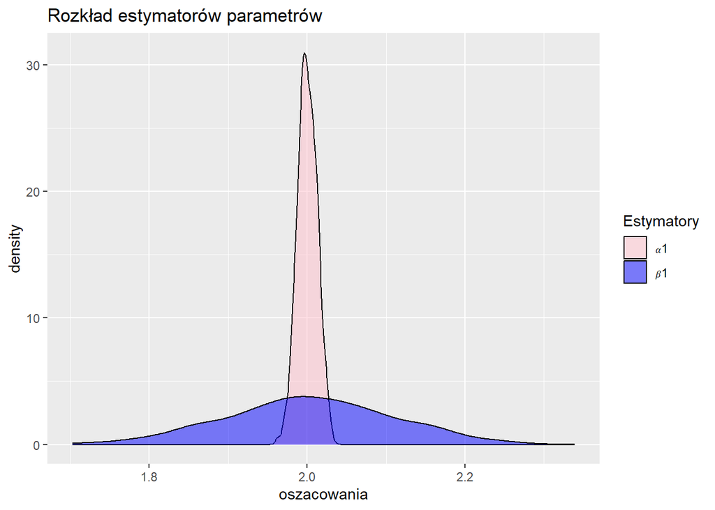

```r
df%>%
  pivot_longer(cols=c("est_x1","po_est_x1"),names_to = "przed_po",values_to = "oszacowania")%>%
  ggplot(aes(oszacowania,fill=przed_po))+
  geom_density(alpha=0.5)+
  labs(title="Rozkład estymatorów parametrów",
       fill="Estymatory")+
  scale_fill_manual(labels = c("𝛼1","𝛽1"),values = c("pink","blue"))
```

Badanie normalności powyższych rozkładów:

```r
cat("𝛼1: Shapiro-Wilk", shapiro.test(df$est_x1)$p.value,
    "\n𝛼1: Lillieforse", lillie.test(df$po_est_x1)$p.value,
    "\n𝛽1: Shapiro-Wilk", shapiro.test(df$est_x1)$p.value,
    "\n𝛽1: Lillieforse", lillie.test(df$po_est_x1)$p.value)
```

```
## 𝛼1: Shapiro-Wilk 0.2249055
## 𝛼1: Lillieforse 0.5864732
## 𝛽1: Shapiro-Wilk 0.2249055
## 𝛽1: Lillieforse 0.5864732
```

Wnioski:

## Badanie obciążoności

```r
cat("wartość oczekiwana 𝛼1: ",mean(df$est_x1),"\nwartość oczekiwana 𝛽1: ",mean(df$po_est_x1), "\nrelative_error_𝛼1:",mean(abs((a - df$est_x1) /a)), "\nrelative_error_𝛽1:",mean(abs((a - df$po_est_x1) /a)),"\nMSE_𝛼1:",mean((a - df$est_x1)^2),"\nMSE_𝛽1:",mean((a - df$po_est_x1)^2))
```

```
## wartość oczekiwana 𝛼1:  2.000078
## wartość oczekiwana 𝛽1:  2.003039
## relative_error_𝛼1: 0.004979291
## relative_error_𝛽1: 0.04235294
## MSE_𝛼1: 0.000151669
## MSE_𝛽1: 0.01125983
```

Wnioski:

- Wartość oczekiwana w obydwóch przypadkach jest bardzo podobna
- Relative error parametru 𝛽1 jest większy od 𝛼1, więc estymator będzie popełniał większy błąd oszacowania
- Błąd średniokwartylowy (MSE) również jest większy w przypadku estymatora 𝛽1, czyli jest on mniej dokładny niż estymator 𝛼1

# Statystyka t w testach

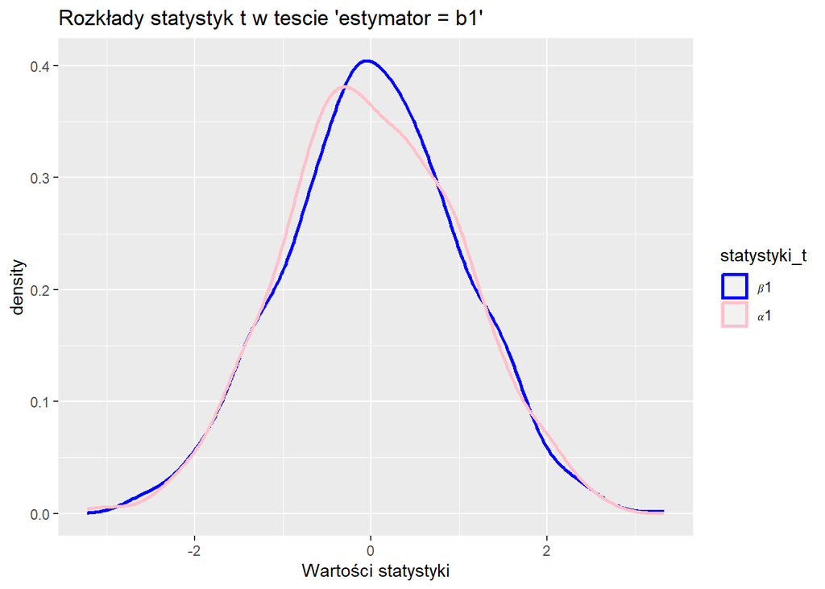

```r
df%>%
  pivot_longer(cols=c("stat_t_x1","po_stat_t_x1"),names_to = "statystyki_t",values_to = "wartosci")%>%
  ggplot(aes(wartosci,color=statystyki_t))+
  geom_density(alpha=0.5,linewidth=1)+
  labs(title="Rozkłady statystyk t w tescie 'estymator = b1' ",fill="Estymatory",x="Wartości statystyki")+
  scale_color_manual(labels = c("𝛽1","𝛼1"),values = c("blue","pink"))
```

Badanie normalności powyższych rozkładów:

```r
cat("PRZED: Shapiro-Wilk", shapiro.test(df$stat_t_x1)$p.value,
    "\nPRZED: Lillieforse", lillie.test(df$po_stat_t_x1)$p.value,
    "\nPO: Shapiro-Wilk", shapiro.test(df$stat_t_x1)$p.value,
    "\nPO: Lillieforse", lillie.test(df$po_stat_t_x1)$p.value)
```

```
## PRZED: Shapiro-Wilk 0.2697321
## PRZED: Lillieforse 0.9671416
## PO: Shapiro-Wilk 0.2697321
## PO: Lillieforse 0.9671416
```

## Hipotezy testów:

H0: 𝛼1 = b1

H1: 𝛼1 != b1

Dla 𝛼1 (wersja z dwoma istotnymi zmiennymi):

```r
table(df$ist_x1)
```

```
##
##   0   1
## 976  48
```

H0: 𝛽1 = b1

H1: 𝛽1 != b1

Dla 𝛽1 (wersja z pominiętą zmienną istotną):

```r
table(df$po_ist_x1)
```

[output not shown]

1 - oszacowany parametr różni się istotnie od odpowiadającej wartości teoretycznej (b1)

0 - oszacowany parametr nie różni się istotnie od odpowiadającej wartości teoretycznej (b1)

Wnioski:

- Rozkład wartości statystyki nie różni się zbytnio w obydwóch przypadkach i praktycznie większość wartości znajduje się w przedziale od -2 do 2, co oznacza że przyjmujemy hipotezę, że estymator=b1
- W tabelkach potwierdza się, to co widzimy na wykresie gęstości - praktycznie w każdym przypadku została przyjęta hipoteza H0, niezależnie czy model miał dwie zmienne objaśniające czy jedną

# Wpływ na współczynnik determinacji R

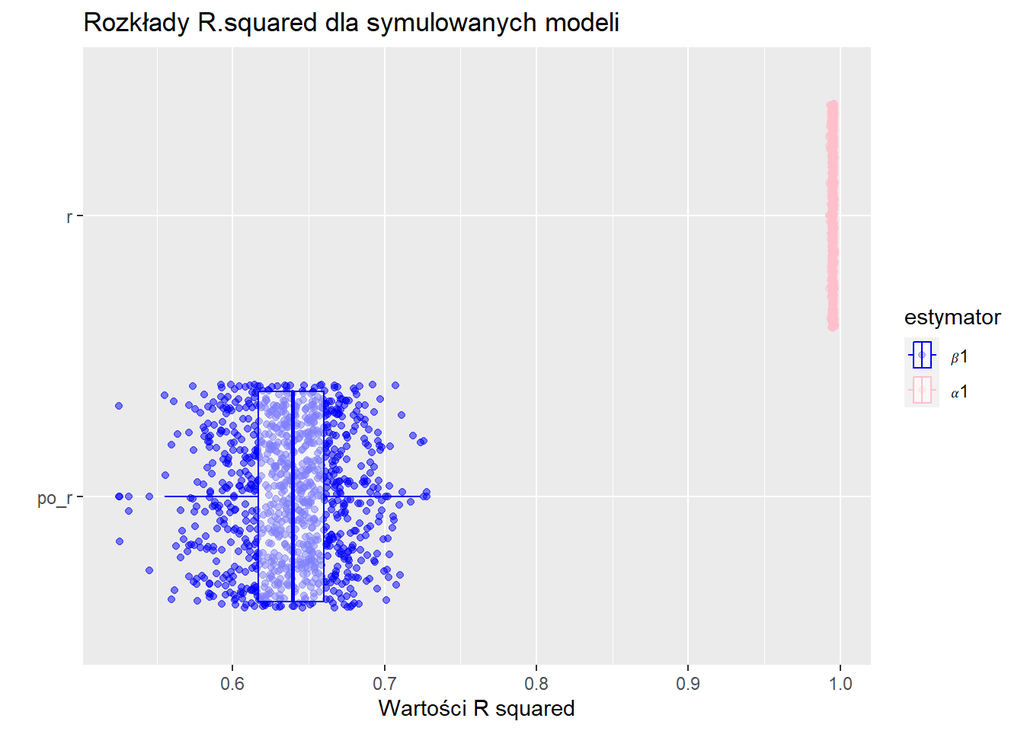

```r
df%>%
  pivot_longer(cols=c("po_r","r"),names_to = "regular_R_squared",values_to = "wartosci")%>%
  ggplot(aes(wartosci,y=regular_R_squared,color=regular_R_squared))+
  geom_jitter(alpha=.5)+
  geom_boxplot(alpha=0.5)+
  labs(title="Rozkłady R.squared dla symulowanych modeli",
       x="Wartości R squared",
       y="",
       color="estymator")+
  scale_color_manual(labels = c("𝛽1","𝛼1"),values = c("blue","pink"))
```

## Wpływ na skorygowany współczynnik determinacji R

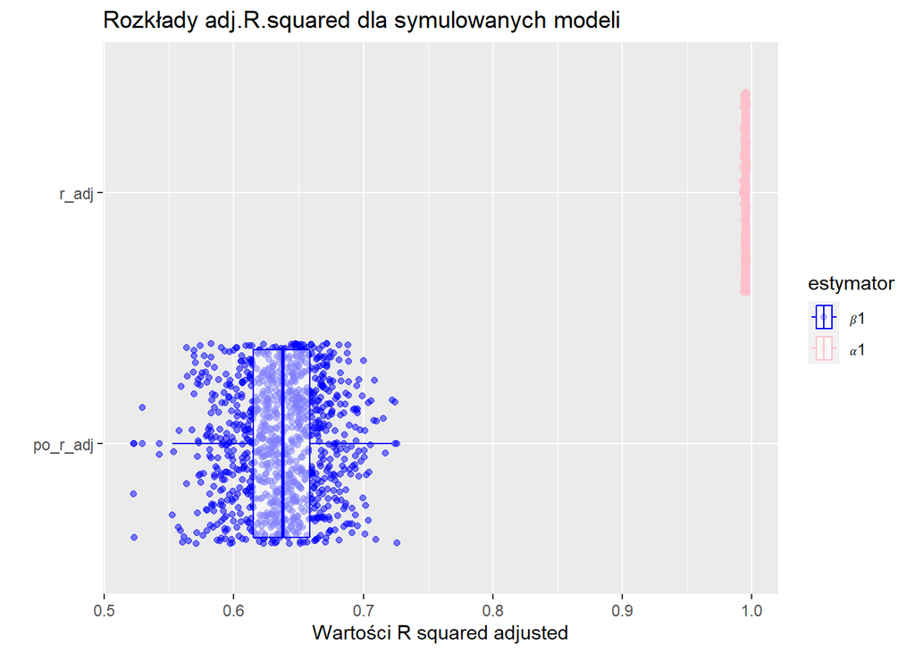

```r
df%>%
  pivot_longer(cols=c("po_r_adj","r_adj"),names_to = "adjusted_R_squared",values_to = "wartosci")%>%
  ggplot(aes(wartosci,y=adjusted_R_squared,color=adjusted_R_squared))+
  geom_jitter(alpha=.5)+
  geom_boxplot(alpha=0.5)+
  labs(title="Rozkłady adj.R.squared dla symulowanych modeli",
       x="Wartości R squared adjusted",
       y="",
       color="estymator")+
  scale_color_manual(labels = c("𝛽1","𝛼1"),values = c("blue","pink"))
```

Wnioski;

- Współczynnik R^2 w przypadku gdy mamy model z dwoma istotnymi zmiennymi prakytcznie zawsze wynosi 1, co oznacza, że model bardzo dobrze szacuje wartości.
- W przypadku wariantu, gdy pomijamy jedną istotną zmienną model nie jest już tak dokładny i R^2 jest dużo niższe. W naszym przypadku większość wartości R^2 oscyluje wokół wartości 0.65.
- Skorygowany współczynnik determinacji R zachowuje się bardzo podobnie jak współczynnik R.

# Zmiana wartości współczynnika przy drugiej istotnej zmiennej

```r
df<-data.frame("est_x1"=0,"stat_t_x1"=0,"ist_x1"=0,"r_adj"=0,"r"=0,"po_est_x1"=0,"po_stat_t_x1"=0,"po_ist_x1"=0,"po_r_adj"=0,"po_r"=0,"b"=0)

for(j in c(-60,-30,-6,-2,-0.5,0.5,2,6,30,60)){
  for(i in 1:1024)
  {

    x1<-runif(n,0,20)
    x2<-runif(n,0,10)
    e<-rnorm(n,0,1)
    Y<-a*x1 + j*x2 +e + c
    #przed
    model=lm(Y~x1+x2)
    x1_est=as.numeric(summary(model)$coefficients[,1][2])
    t_x1<-(x1_est - a)/as.numeric(summary(model)$coefficients[,2][2])#statystyka t-studenta dla alfa=0.05
    ist_x1<-abs(t_x1)>qt(1 - 0.05/2, 50-3)
    r_adj<-summary(model)$adj.r.squared
    r<-summary(model)$r.squared

    #po
    model2=lm(Y~x1)
    po_x1_est=as.numeric(summary(model2)$coefficients[,1][2])
   po_t_x1<-(po_x1_est - a)/as.numeric(summary(model2)$coefficients[,2][2])#statystyka t-studenta dla alfa=0.05
    po_ist_x1<-abs(po_t_x1)>qt(1 - 0.05/2, 50-3)
    po_r_adj<-summary(model2)$adj.r.squared
    po_r<-summary(model2)$r.squared
    df<-rbind(df,c(x1_est,t_x1,ist_x1,r_adj,r,po_x1_est,po_t_x1,po_ist_x1,po_r_adj,po_r,j))


}
}
df<-df[-1,]
rownames(df)<-NULL
```

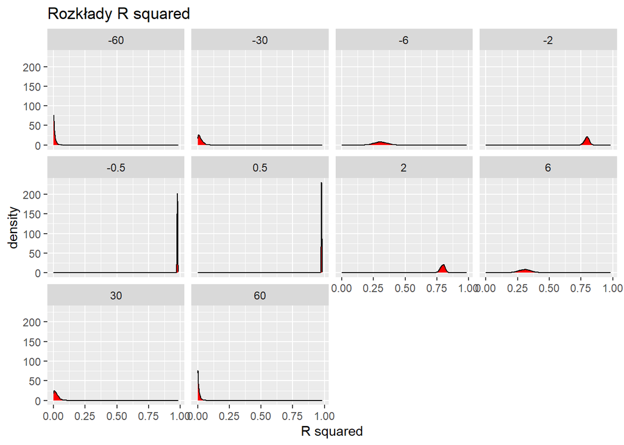

```r
ggplot(df,aes(x=po_r))+
  geom_density(fill="red")+
  facet_wrap(~b,nrow=3)+
  labs(title="Rozkłady R squared",
       x="R squared",
       fill="wartość b")
```

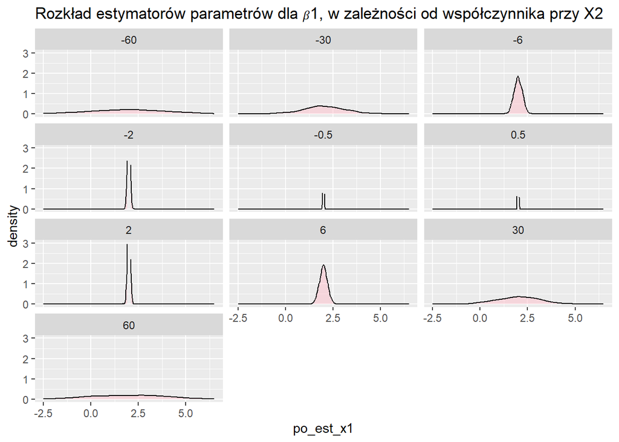

```r
df%>%
  ggplot(aes(po_est_x1))+
  geom_density(alpha=0.5,fill="pink")+
  ylim(0,3)+
  xlim(-2.5,6.5)+
  facet_wrap(~b,ncol = 3)+
  labs(title="Rozkład estymatorów parametrów dla 𝛽1, w zależności od współczynnika przy X2")
```

Wnioski:

- Wraz ze wzrostem wartości bezwzględnej maleje R squared dla modelu z pominiętą istotną zmienną - jest to spowodowane tym, że im mocniejszy wpływ ta druga istotna zmienna miała na model tym bardziej będzie zaburzać to estymacje modelu w którym ją pomijamy.
- Wraz ze wzrostem wartośći bezwzględnej współczynnika rośnie wariancja (rozkład robi się bardziej płaski), natomiast przy spadku wartości bezwzględnej współczynnika maleje wariancja (rozkład jest bardzej szpiczasty i skupiony wokół jednej wartości).

**Utworzyliśmy też kilka wykresów, które można samemu ustawiać, aby zrozumieć co dzieje się przy zmianach współczynników. Znajdują się one pod tym linkiem: https://2yo13d-kacpro94.shinyapps.io/Projekt3/**